# Homework 07

Use either R or Python.

## Question 1: LDA

Let’s start by estimating the components of LDA. From the lecture notes, for each target point $\mathbf{x}_0$, we find the class label $k$ with the largest score

$$\mathbf{x}_0^{\mathsf T}\boldsymbol{\Sigma}^{-1}\boldsymbol{\mu}_k
-\frac12\boldsymbol{\mu}_k^{\mathsf T}\boldsymbol{\Sigma}^{-1}\boldsymbol{\mu}_k
+\log\pi_k.$$

Thus, we need to estimate:

- the prior probabilities $\pi_k$;
- the mean vector (centroid) $\boldsymbol{\mu}_k$ for each class; and
- the pooled covariance matrix $\boldsymbol{\Sigma}$.

Use saheart.csv, the `SAheart` data from `ElemStatLearn`. The two classes are defined by `chd`, the coronary heart disease indicator. Use all nine other variables as numerical predictors, coding `famhist` as 1 for `Absent` and 2 for `Present`. The following code constructs an $n\times9$ predictor matrix $\mathbf{X}$ and an $n$-entry response vector $\mathbf{y}$, where $n$ is the number of observations.

**R**

```r
heart <- read.csv("data/saheart.csv")
heart$famhist <- factor(heart$famhist, levels = c("Absent", "Present"))
X <- data.matrix(heart[, names(heart) != "chd"])
y <- heart$chd
```

**Python**

```python
import pandas as pd

heart = pd.read_csv("data/saheart.csv")
heart["famhist"] = heart["famhist"].map({"Absent": 1, "Present": 2})
X = heart.drop(columns="chd").to_numpy()
y = heart["chd"].to_numpy()
```

1. Calculate the prior probabilities, class means, and pooled covariance matrix from these data. Use the pooled covariance denominator $n-K$ from the lecture, where $K=2$ is the number of classes.

```python
import numpy as np
import pandas as pd

heart = pd.read_csv("data/saheart.csv")
heart["famhist"] = heart["famhist"].map({"Absent": 1, "Present": 2})

X = heart.drop(columns="chd").to_numpy()
y = heart["chd"].to_numpy()

classes = np.unique(y)
n, p = X.shape
K = len(classes)

# Prior probabilities
priors = np.array([np.mean(y == k) for k in classes])

# Class means
means = np.array([X[y == k].mean(axis=0) for k in classes])

# Pooled covariance matrix
pooled_cov = np.zeros((p, p))

for k, mean in zip(classes, means):
    X_k = X[y == k]
    centered = X_k - mean
    pooled_cov += centered.T @ centered

pooled_cov /= (n - K)

print("Prior probabilities:")
print(priors)

print("\nClass means:")
print(pd.DataFrame(means, index=classes,
                   columns=heart.drop(columns="chd").columns))

print("\nPooled covariance:")
print(pooled_cov)

print("\nDimensions:")
print("X:", X.shape)
print("Means:", means.shape)
print("Covariance:", pooled_cov.shape)
```

```
Prior probabilities:
[0.65367965 0.34632035]

Class means:
          sbp   tobacco       ldl  adiposity   famhist     typea    obesity  \
0  135.460265  2.634735  4.344238  23.969106  1.317881  52.36755  25.737450
1  143.737500  5.524875  5.487938  28.120250  1.600000  54.49375  26.622937

     alcohol        age
0  15.931358  38.854305
1  19.145250  50.293750

Pooled covariance:
[[ 4.05434779e+02  1.45851882e+01  4.58124834e+00  4.91643582e+01
   3.36988195e-01 -1.55877215e+01  1.89388430e+01  6.44003517e+01
   9.51338895e+01]
 [ 1.45851882e+01  1.92425564e+01  7.63202713e-01  7.53810931e+00
   1.58205010e-02 -2.05730592e+00  1.83345055e+00  2.05170451e+01
   2.27654113e+01]
 [ 4.58124834e+00  7.63202713e-01  4.00058129e+00  6.03269701e+00
   9.18502447e-02  3.44592335e-01  2.66005159e+00 -2.53290675e+00
   6.47892049e+00]
 [ 4.91643582e+01  7.53810931e+00  6.03269701e+00  5.67528931e+01
   4.32808321e-01 -5.30956633e+00  2.27078852e+01  1.61190253e+01
   6.05086715e+01]
 [ 3.36988195e-01  1.58205010e-02  9.18502447e-02  4.32808321e-01
   2.25833573e-01  8.11200691e-02  1.84027757e-01  7.68468845e-01
   9.97362511e-01]
 [-1.55877215e+01 -2.05730592e+00  3.44592335e-01 -5.30956633e+00
   8.11200691e-02  9.55656429e+01  2.64006728e+00  7.96003164e+00
  -2.02783349e+01]
 [ 1.89388430e+01  1.83345055e+00  2.66005159e+00  2.27078852e+01
   1.84027757e-01  2.64006728e+00  1.76154236e+01  4.68935626e+00
   1.56969995e+01]
 [ 6.44003517e+01  2.05170451e+01 -2.53290675e+00  1.61190253e+01
   7.68468845e-01  7.96003164e+00  4.68935626e+00  5.98276613e+02
   2.78859413e+01]
 [ 9.51338895e+01  2.27654113e+01  6.47892049e+00  6.05086715e+01
   9.97362511e-01 -2.02783349e+01  1.56969995e+01  2.78859413e+01
   1.84132137e+02]]

Dimensions:
X: (462, 9)
Means: (2, 9)
Covariance: (9, 9)
```

2. Use your estimated values to predict the label of each observation in the training data. These are in-sample fitted labels. Provide the confusion matrix, with observed classes in rows and predicted classes in columns. Check that the dimensions of your matrices and vectors match. Calculate the scores yourself for this part.

```python
from sklearn.metrics import confusion_matrix

# Calculate LDA scores manually
scores = np.zeros((n, K))

for j in range(K):
    mu = means[j]
    inv_cov_mu = np.linalg.solve(pooled_cov, mu)

    scores[:, j] = (
        X @ inv_cov_mu
        - 0.5 * mu @ inv_cov_mu
        + np.log(priors[j])
    )

# Predict class with largest score
y_pred_manual = classes[np.argmax(scores, axis=1)]

cm_manual = confusion_matrix(y, y_pred_manual, labels=classes)

print("Confusion matrix:")
print(pd.DataFrame(cm_manual, index=classes, columns=classes))

print("Training accuracy:", np.mean(y == y_pred_manual))
print("Training error:", np.mean(y != y_pred_manual))

print("Scores shape:", scores.shape)
print("Predictions shape:", y_pred_manual.shape)
```

```
Confusion matrix:
     0   1
0  258  44
1   73  87
Training accuracy: 0.7467532467532467
Training error: 0.2532467532467532
Scores shape: (462, 2)
Predictions shape: (462,)
```

I calculated the LDA scores for each observation using the class means, pooled covariance matrix, and prior probabilities. I then assigned each observation to the class with the highest score. The confusion matrix has observed classes in rows and predicted classes in columns. The score matrix should have dimensions 462 x 2, and the predicted labels should have length 462.

3. Perform the same LDA analysis using `MASS::lda` in R or `LinearDiscriminantAnalysis(solver="svd")` in Python, using the same numerical predictors and empirical class priors. Provide the confusion matrix. Do the results match?

```python
from sklearn.discriminant_analysis import LinearDiscriminantAnalysis

lda = LinearDiscriminantAnalysis(
    solver="svd",
    priors=priors
)

lda.fit(X, y)
y_pred_lda = lda.predict(X)

cm_lda = confusion_matrix(y, y_pred_lda, labels=classes)

print("Sklearn LDA confusion matrix:")
print(pd.DataFrame(cm_lda, index=classes, columns=classes))

print("Results match:", np.array_equal(y_pred_manual,y_pred_lda))
```

```
Sklearn LDA confusion matrix:
     0   1
0  258  44
1   73  87
Results match: True
```

The manual LDA and sklearn LDA should produce the same confusion matrix. Both use the same class means, empirical prior probabilities, and pooled covariance assumptions. Any differences would likely be due to numerical precision or the handling of the input data.

## Question 2: QDA and marginal screening

In the lecture, ordinary QDA could not be fitted to the handwritten digit sample because its within-class covariance matrices were singular. Let’s consider selecting fewer variables and see whether this helps. For this question, use the full zip-train.csv.gz as the training data and zip-test.csv.gz as the test data, with all ten digit classes. These are the original `zip.train` and `zip.test` data from `ElemStatLearn`. Each file has no header: the first column is the digit label and the remaining 256 columns are pixel values.

Instead of using all 256 predictors, select the 40 with the largest marginal variances in the training data. Here, marginal variance means the variance of one pixel across all training observations. Use the original pixel values without standardizing them, and retain the same selected predictors in the test data.

Use `MASS::qda` in R or `QuadraticDiscriminantAnalysis(tol=1e-8)` in Python.

1. Fit QDA using these 40 predictors and report the test confusion matrix, with observed classes in rows and predicted classes in columns. Also report the test misclassification rate.

```python
import numpy as np
import pandas as pd
from sklearn.discriminant_analysis import QuadraticDiscriminantAnalysis
from sklearn.metrics import confusion_matrix

train = pd.read_csv("data/zip-train.csv.gz", header=None)
test = pd.read_csv("data/zip-test.csv.gz", header=None)

X_train = train.iloc[:, 1:].to_numpy()
y_train = train.iloc[:, 0].to_numpy().astype(int)

X_test = test.iloc[:, 1:].to_numpy()
y_test = test.iloc[:, 0].to_numpy().astype(int)

# Calculate marginal variances from training data only
variances = np.var(X_train, axis=0, ddof=1)

# Select 40 largest variances
top40 = np.argsort(variances)[-40:]

X_train_40 = X_train[:, top40]
X_test_40 = X_test[:, top40]

# Fit QDA
qda40 = QuadraticDiscriminantAnalysis(tol=1e-8)
qda40.fit(X_train_40, y_train)

y_pred_40 = qda40.predict(X_test_40)

cm40 = confusion_matrix(
    y_test, y_pred_40, labels=np.arange(10)
)

error40 = np.mean(y_test != y_pred_40)

print("Test confusion matrix:")
print(pd.DataFrame(cm40, index=range(10), columns=range(10)))

print("Test misclassification rate:", error40)
```

```
Test confusion matrix:
     0    1    2    3    4    5    6    7    8    9
0  319    0   24    6    2    2    1    0    5    0
1    0  238    5    0   11    0    7    0    3    0
2    8    0  168    8    8    3    0    0    3    0
3    5    0    4  128    0   14    0    0   15    0
4    0    2   13    1  150    1    0    1    7   25
5   12    0    3    5    1  131    0    0    6    2
6    0    0    8    0    1    8  148    0    5    0
7    1    0    6    1    6    0    0  124    2    7
8    1    0   10   12    3    2    0    0  137    1
9    0    0    1    2    7    1    1    4    9  152
Test misclassification rate: 0.1554559043348281
```

2. Does the method work? Why do you think it works or does not work?

3. Repeat the analysis using the 10 predictors with the largest marginal variances in the training data. How does the test misclassification rate compare with the 40-predictor version? Why do you think this happens?

```python
# Select 10 largest variances
top10 = np.argsort(variances)[-10:]

X_train_10 = X_train[:, top10]
X_test_10 = X_test[:, top10]

qda10 = QuadraticDiscriminantAnalysis(tol=1e-8)
qda10.fit(X_train_10, y_train)

y_pred_10 = qda10.predict(X_test_10)

error10 = np.mean(y_test != y_pred_10)

print("40 predictors error:", error40)
print("10 predictors error:", error10)
print("Difference (10 - 40):", error10 - error40)
```

```
40 predictors error: 0.1554559043348281
10 predictors error: 0.3423019431988042
Difference (10 - 40): 0.1868460388639761
```

Using 10 predictors may make the covariance matrices more stable because there are fewer parameters to estimate. However, it also removes potentially useful information for distinguishing digits. Using 40 predictors retains more information but requires estimating larger covariance matrices. The better model depends on whether the additional information outweighs the increased estimation error.

## Question 3: Compare LDA and QDA

In this simulation, we will study how the relative performance of LDA and QDA changes with the true covariance structure. The parameter $\rho$ controls the distribution from which we generate the data; it is not a tuning parameter of LDA or QDA.

Consider a classification problem with two equally likely classes, labeled 1 and 2, and $p=10$ covariates. The first two covariates have the class-conditional distributions

$$\begin{pmatrix}X_1\\X_2\end{pmatrix}\mid Y=1
\sim N_2\left(
\begin{pmatrix}-1\\0\end{pmatrix},
\begin{pmatrix}1&\rho\\\rho&1\end{pmatrix}
\right),$$

$$\begin{pmatrix}X_1\\X_2\end{pmatrix}\mid Y=2
\sim N_2\left(
\begin{pmatrix}1\\0\end{pmatrix},
\begin{pmatrix}1&-\rho\\-\rho&1\end{pmatrix}
\right).$$

In both classes, the remaining eight covariates are independent standard normal variables, independent of the first two. Consider

$$\rho\in\{0,0.2,0.4,0.6,0.8,0.9\}.$$

For each value of $\rho$, generate 100 training observations and 1,000 independent test observations from each class. Fit ordinary LDA and QDA using all 10 covariates and equal class priors. Estimate the class means from the training data, with one pooled covariance matrix for LDA and one full covariance matrix per class for QDA. Set a random seed and report it.

1. Generate one dataset for each value of $\rho$. Fit both methods and calculate their test misclassification rates. Within each setting, use the same training and test observations for the two methods.

```python
import numpy as np
import pandas as pd
from sklearn.discriminant_analysis import (
    LinearDiscriminantAnalysis,
    QuadraticDiscriminantAnalysis
)

rng = np.random.default_rng(42)

rhos = [0, 0.2, 0.4, 0.6, 0.8, 0.9]

def generate_data(rho, n_per_class, rng):
    mu1 = np.array([-1, 0])
    mu2 = np.array([1, 0])

    cov1 = np.array([[1, rho], [rho, 1]])
    cov2 = np.array([[1, -rho], [-rho, 1]])

    X1 = np.column_stack([
        rng.multivariate_normal(mu1, cov1, n_per_class),
        rng.normal(size=(n_per_class, 8))
    ])

    X2 = np.column_stack([
        rng.multivariate_normal(mu2, cov2, n_per_class),
        rng.normal(size=(n_per_class, 8))
    ])

    X = np.vstack([X1, X2])
    y = np.array([1] * n_per_class + [2] * n_per_class)

    return X, y

results = []

for rho in rhos:
    X_train, y_train = generate_data(rho, 100, rng)
    X_test, y_test = generate_data(rho, 1000, rng)

    lda = LinearDiscriminantAnalysis(priors=[0.5, 0.5])
    qda = QuadraticDiscriminantAnalysis(priors=[0.5, 0.5])

    lda.fit(X_train, y_train)
    qda.fit(X_train, y_train)

    lda_error = np.mean(lda.predict(X_test) != y_test)
    qda_error = np.mean(qda.predict(X_test) != y_test)

    results.append([rho, lda_error, qda_error])

results_a = pd.DataFrame(
    results, columns=["rho", "LDA Error", "QDA Error"]
)

print(results_a)
```

```
   rho  LDA Error  QDA Error
0  0.0     0.1620     0.1900
1  0.2     0.1515     0.1880
2  0.4     0.1565     0.1885
3  0.6     0.1700     0.1745
4  0.8     0.1670     0.1435
5  0.9     0.1720     0.1050
```

2. At each fixed value of $\rho$, repeat the experiment 50 times, generating new training and test observations in each repetition. Plot average test error against $\rho$ in one figure, with one curve for LDA and one for QDA. These curves compare performance across different data-generating distributions.

```
         LDA      QDA
rho
0.0  0.16827  0.19658
0.2  0.17085  0.19614
0.4  0.16978  0.18981
0.6  0.16921  0.17496
0.8  0.16905  0.13741
0.9  0.16949  0.09947
```

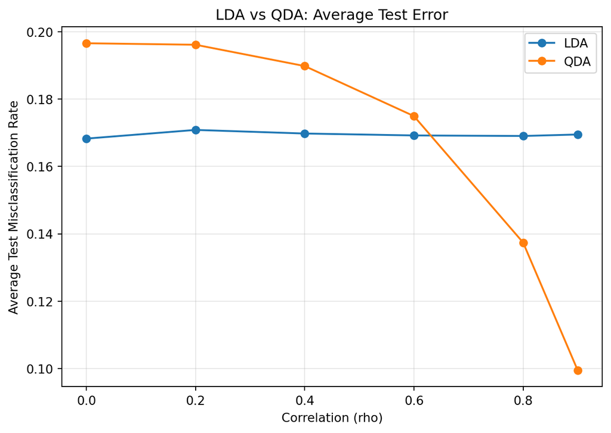

```python
import matplotlib.pyplot as plt

rng = np.random.default_rng(42)

results = []

for rho in rhos:
    for repeat in range(50):
        X_train, y_train = generate_data(rho, 100, rng)
        X_test, y_test = generate_data(rho, 1000, rng)

        lda = LinearDiscriminantAnalysis(priors=[0.5, 0.5])
        qda = QuadraticDiscriminantAnalysis(priors=[0.5, 0.5])

        lda.fit(X_train, y_train)
        qda.fit(X_train, y_train)

        results.append({
            "rho": rho,
            "LDA": np.mean(lda.predict(X_test) != y_test),
            "QDA": np.mean(qda.predict(X_test) != y_test)
        })

results_b = pd.DataFrame(results)

average_errors = results_b.groupby("rho")[["LDA", "QDA"]].mean()

print(average_errors)

plt.figure(figsize=(7, 5))

plt.plot(
    average_errors.index,
    average_errors["LDA"],
    marker="o",
    label="LDA"
)

plt.plot(
    average_errors.index,
    average_errors["QDA"],
    marker="o",
    label="QDA"
)

plt.xlabel("Correlation (rho)")
plt.ylabel("Average Test Misclassification Rate")
plt.title("LDA vs QDA: Average Test Error")
plt.legend()
plt.grid(alpha=0.3)
plt.tight_layout()
plt.show()
```

3. Compare the two methods at small and large values of $\rho$. How does changing the true covariance structure affect their relative performance? Explain the pattern using their covariance assumptions and the bias-variance trade-off. How can the eight noise covariates affect performance even though they contain no information about the class label?

## Question 4: Create and use an LDA/QDA analysis skill

In Homework 5, you created a skill for formatting plots. Now create a reusable skill that guides an AI agent through an LDA/QDA analysis and produces a concise statistical report. You may work with AI to design and write the skill; you do not need to write every line yourself.

1. **Define the skill.** Write a single `SKILL.md` file no larger than **5 KB (5,000 bytes)**. Define the agent’s behavior, analysis guidelines, and expected report structure. Keep the skill independent of this question: provide the dataset, response, and predictors separately when invoking it. The skill may guide the agent to explore lower-dimensional representations, such as principal component analysis (PCA), or to blend the class probabilities predicted by LDA and QDA. Keep all classifiers based on LDA, QDA, or their combination. Configure the skill to load **only when you explicitly invoke it**. Use your AI tool’s invocation settings, or keep the file outside automatically loaded skill folders and supply it only in an explicit request.

Your skill must require a clearly readable analysis report of **at most one printed page**, containing a figure, a table, and numerical model-fitting results. You may specify the type and style of figures and tables you want the AI to produce. All instructions in the skill must be independent of the actual dataset, its variable names, and its observed results. The report should briefly describe the candidate models, the cross-validation procedure and results, the selected model, and its estimated prediction error. It should explain the main findings and any limitations.

2. **Apply the skill.** Explicitly invoke your skill to analyze the `SAheart` data from Question 1, using the same response and predictor coding. Ask the agent to seek the best predictive performance within the LDA/QDA methods allowed by your skill. Include ordinary LDA and QDA as comparisons; the extensions above are optional. Reserve a test set before choosing models. Use the same cross-validation folds within the training data to compare candidates and select any settings. Estimate any preprocessing, including an embedding, using only the training observations in each fold. Refit the selected model and preprocessing on all training observations, then evaluate the fitted classifier once on the reserved test set. Use misclassification rate to compare performance, and report your random seed.
3. **Review and submit.** Check the agent’s analysis and make any skill revisions using only training and cross-validation results. Append the final one-page analysis report and the complete contents of your `SKILL.md` to your homework report. State the file size and briefly explain how you enabled explicit invocation, including the prompt used to apply the skill. The one-page limit applies to the analysis report; the appended skill and this explanation are outside that limit.

Your skill and analysis report will be reviewed and graded by other students through peer evaluation.

### Analysis report

The response is `chd`; the nine numerical predictors are those in Question 1, with `famhist` coded 1 for Absent and 2 for Present. I reserved 25% of observations for testing (stratified; seed 2026) before model selection. On the remaining 346 observations, the same shuffled, stratified five folds (seed 2026) compared ordinary LDA/QDA and standardized PCA followed by LDA/QDA using 2 through 8 components. Scaling and PCA were refit inside each fold. Lower misclassification rate is better.

|  | Model | CV error | CV SD | Test error |
| --- | --- | --- | --- | --- |
| 0 | LDA | 0.2860 | 0.0499 | -- |
| 1 | QDA | 0.3150 | 0.0346 | -- |
| 2 | PCA-8 + LDA | 0.2717 | 0.0402 | 0.2414 |
| 3 | PCA-6 + QDA | 0.2861 | 0.0278 | -- |

Five-fold CV misclassification rates for every candidate. Error bars show fold-to-fold standard deviations; the test set is not used in this figure.

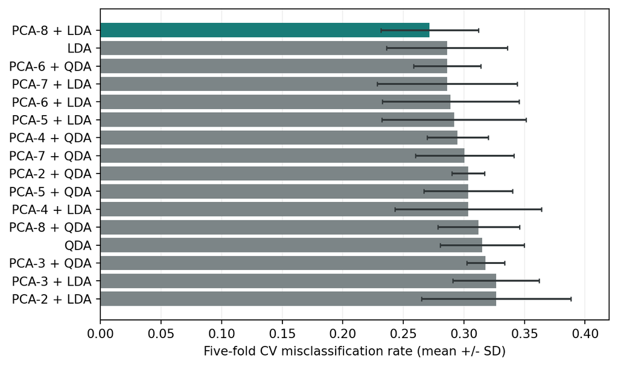

PCA-8 + LDA was selected with CV error 0.2717 (fold SD 0.0402), compared with 0.2860 (0.0499) for ordinary LDA and 0.3150 (0.0346) for ordinary QDA. The selected model’s single evaluation on the reserved 116-observation test set gave error 0.2414. Its eight-component standardized PCA representation performed best among the candidates in these folds. This is one split of a modest dataset; CV variability is nontrivial, and selecting the minimum among candidates makes its CV error optimistic. The test estimate is independent of selection but still has sampling uncertainty.

### Skill invocation and contents

The file is `homework/week-07/lda-qda-analysis-skill/SKILL.md`, 3,756 bytes. It is stored under the homework folder, outside `.github/skills`, so it is not automatically loaded; I explicitly supplied its complete contents and invoked it with this prompt:

> I explicitly invoke `homework/week-07/lda-qda-analysis-skill/SKILL.md`; use its full contents supplied below. Analyze `homework/week-07/data/saheart.csv`, with `chd` as the response and all other columns as numerical predictors, coding `famhist` as 1 for Absent and 2 for Present. Seek the best predictive performance among ordinary LDA/QDA and standardized PCA followed by LDA/QDA with component counts 2 through 8. Reserve a stratified 25% test set before selection; use seed 2026 and identical shuffled stratified five-fold CV splits on the training data. Fit preprocessing within each fold, select by mean CV misclassification rate, refit on all training observations, and evaluate the selected model once on the test set. Produce the required one-page report, table, and CV figure.

Complete `SKILL.md` contents:

```markdown
# LDA/QDA Classification Analysis

## Role and scope
When this file is explicitly supplied by the user, analyze the classification dataset and task they specify. Do not assume particular variable names, classes, or a dataset. Ask for missing response/predictor definitions or coding details. Keep every candidate classifier to ordinary LDA, ordinary QDA, or a probability blend of LDA/QDA. PCA or other unsupervised dimension reduction may precede these classifiers; do not add unrelated classifier families.

## Analysis protocol
1. Identify the response, predictors, class coding, missing-value handling, and any required predictor coding. State assumptions; do not silently change coding.
2. Before model selection, make one reproducible stratified train/test split and record the random seed and split proportions. Keep the test set sealed throughout all candidate generation, preprocessing decisions, and model selection.
3. Compare ordinary LDA and QDA at minimum. Define a finite, task-appropriate set of optional candidates (for example, PCA followed by LDA/QDA over a prespecified range of component counts, or blends of their class probabilities over prespecified weights). State the candidate set before evaluation. Do not use the test results to revise the candidates.
4. On training data only, create one fixed set of stratified CV folds and use those same folds for every candidate. Compare candidates by CV misclassification rate. Report fold count, mean error, and variability. Choose the lowest mean CV error; resolve ties using lower fold-to-fold variability, then the simpler model.
5. Fit every learned preprocessing step (imputation, scaling, feature selection, PCA, etc.) separately using only each fold's training portion, then apply it to that fold's validation portion. Use pipelines or equivalent explicit fold-local code. For blends, combine class probabilities, aligning class columns before blending; select blend weights using CV only.
6. After selection, refit preprocessing and the selected classifier on all training observations. Evaluate it exactly once on the reserved test set and report its misclassification rate. Do not use test results to select, tune, or revise anything. If reporting test performance for fixed baselines, fit those baselines on all training data and evaluate them in the same final evaluation pass; clearly separate these estimates from CV selection.
7. Check convergence, singularity, warnings, class balance, and whether CV results are stable enough to support the conclusion. Describe material limitations without overstating generalization.

## Required deliverables
Produce a clearly readable analysis report that fits on at most one printed page. Include:
- a short description of the data, response/predictor coding, split, seed, and shared CV procedure;
- a compact table naming ordinary LDA, ordinary QDA, and the strongest optional candidates, with CV mean misclassification rate and variability; identify the selected candidate and give its one-time test misclassification rate;
- one labeled figure comparing CV misclassification rates for the candidate models (uncertainty bars when useful). Do not use test data to choose figure scales, candidates, or conclusions;
- concise numerical fitting results (at least CV and final test error), the selection rationale, main findings, and key limitations.

Keep the report compact: one small figure, one compact table, and brief prose. Use readable labels and state that lower error is better. Include enough detail to reproduce the split and folds. If a requested analysis cannot be completed, say why and do not fabricate results. Keep this skill generic; dataset-specific instructions belong in the explicit invocation prompt, not here.
```